# The Chaser Game Show Analysis

Raz Ronen & Yuval Rubinshtein

## Results

### Intro

# Background:

• The chaser is a well-known TV quiz show broadcast on Kan11.

• Each team has 4 players. Their goal is to beat the chaser and win as much money as they can.

• For the rules of the game, visit: chaser_wiki

# The Data:

# Goals:

- Our main goal is to track after the pattern of players who won the chaser, we will try to examine how the group’s age distribution and gender distribution affect the winning ratio
- We also want to understand better the players who took risks- who tend to take more risks?

### Importing & Tidying

First, import the relevant libraries:

```r
library(tidyverse)
library (ggplot2)
library (readr)
library(dplyr)
library(matrixStats)
library(grid)
library(gridExtra)
library(tidyr)
library(ggcorrplot)
library(car)
```

Second, load our data from the csv file:

```r
raw_data <- readr::read_csv("https://raw.githubusercontent.com/YuvalRubinstein99/Data_Analytics_Course/main/The_Chase__Dataset.csv")
```

Now, lets get to know our data better:

```r
glimpse(raw_data)
```

```
## Rows: 101
## Columns: 24
## $ p_1_gender          <chr> "male", "male", "female", "male", "male", "male", "female", "male", "male", "male", "female", "female", "male", "female", "male", "male", "female~
## $ p_1_age             <dbl> 30, 45, 33, 34, 50, 53, 26, 21, 38, 32, 38, 67, 29, 28, 34, 23, 31, 43, 29, 30, 35, 31, 32, 26, 27, 35, 29, 23, 28, 39, 50, 40, 33, 47, 60, 35, 5~
## $ p_1_fast_round_sum  <dbl> 20000, 35000, 25000, 35000, 30000, 45000, 40000, 30000, 30000, 35000, 40000, 40000, 30000, 30000, 30000, 35000, 30000, 20000, 30000, 25000, 35000~
## $ p_1_play_sum_chosen <dbl> 20000, 35000, 25000, 35000, 90000, 45000, 40000, 30000, 30000, 35000, 40000, 40000, 120000, 30000, 30000, 35000, 5000, 20000, 30000, 25000, 35000~
## $ p1_round_status     <dbl> 1, 1, 1, 1, 0, 0, 1, 0, 1, 1, 0, 1, 0, 1, 1, 1, 1, 1, 1, 1, 0, 0, 1, 1, 1, 1, 0, 0, 1, 1, 1, 1, 1, 1, 1, 0, 1, 1, 1, 1, 1, 1, 0, 1, 1, 0, 0, 1, 0~
## $ p_2_gender          <chr> "female", "female", "male", "female", "female", "female", "male", "female", "male", "female", "male", "male", "female", "male", "female", "female~
## $ p_2_age             <dbl> 27, 67, 57, 29, 38, 41, 31, 34, 56, 34, 37, 42, 38, 50, 31, 29, 55, 38, 30, 46, 28, 52, 20, 64, 34, 28, 38, 49, 24, 24, 28, 32, 44, 29, 37, 61, 3~
## $ p_2_fast_round_sum  <dbl> 50000, 30000, 20000, 30000, 35000, 30000, 15000, 25000, 35000, 40000, 10000, 35000, 15000, 35000, 35000, 20000, 20000, 55000, 25000, 10000, 10000~
## $ p_2_play_sum_chosen <dbl> 50000, 30000, 20000, 30000, 35000, 9000, 15000, 25000, 10000, 40000, 10000, 100000, 15000, 35000, 35000, 20000, 20000, 150000, 25000, 70000, 1000~
## $ p_2_round_status    <dbl> 1, 0, 1, 1, 1, 1, 1, 1, 1, 1, 1, 0, 0, 1, 1, 0, 1, 1, 1, 0, 0, 1, 1, 1, 0, 1, 1, 0, 1, 1, 1, 0, 1, 1, 1, 0, 1, 0, 0, 0, 1, 1, 1, 0, 1, 1, 1, 0, 1~
## $ p_3_gender          <chr> "male", "female", "female", "female", "female", "male", "female", "male", "female", "male", "female", "female", "male", "male", "female", "female~
## $ p_3_age             <dbl> 56, 30, 38, 24, 31, 31, 22, 37, 27, 36, 29, 32, 55, 25, 28, 43, 37, 29, 61, 32, 47, 30, 29, 25, 64, 33, 45, 26, 38, 33, 27, 26, 27, 20, 35, 26, 2~
## $ p_3_fast_round_sum  <dbl> 35000, 20000, 15000, 25000, 35000, 30000, 30000, 40000, 25000, 15000, 30000, 35000, 30000, 30000, 5000, 15000, 20000, 30000, 15000, 20000, 10000,~
## $ p_3_play_sum_chosen <dbl> 35000, 20000, 15000, 25000, 35000, 150000, 30000, 40000, 25000, 145000, 30000, 35000, 30000, 30000, 50000, 90000, 20000, 30000, 15000, 20000, 100~
## $ p_3_round_status    <dbl> 1, 1, 1, 1, 1, 1, 0, 1, 1, 0, 1, 0, 1, 0, 0, 0, 0, 0, 1, 0, 1, 1, 0, 1, 1, 0, 1, 1, 1, 0, 1, 1, 0, 0, 1, 0, 1, 1, 1, 1, 0, 0, 1, 0, 1, 1, 0, 0, 1~
## $ p_4_gender          <chr> "female", "male", "male", "male", "male", "female", "male", "female", "female", "female", "male", "male", "female", "female", "male", "male", "fe~
## $ p_4_age             <dbl> 30, 33, 32, 32, 30, 44, 40, 34, 39, 37, 35, 30, 40, 28, 51, 39, 62, 36, 35, 47, 30, 29, 30, 41, 33, 62, 32, 33, 41, 29, 30, 37, 29, 36, 43, 34, 3~
## $ p_4_fast_round_sum  <dbl> 30000, 50000, 40000, 20000, 25000, 45000, 50000, 25000, 20000, 50000, 55000, 40000, 30000, 40000, 30000, 40000, 40000, 55000, 25000, 45000, 15000~
## $ p_4_play_sum_chosen <dbl> 30000, 160000, 140000, 90000, 25000, 45000, 50000, 110000, 20000, 50000, 200000, 40000, 150000, 40000, 30000, 40000, 160000, 55000, 25000, 150000~
## $ p_4_round_status    <dbl> 0, 1, 0, 0, 0, 1, 1, 1, 1, 1, 1, 1, 1, 1, 1, 1, 1, 1, 0, 1, 1, 1, 1, 0, 0, 1, 1, 1, 1, 1, 1, 1, 1, 0, 1, 1, 1, 0, 0, 0, 1, 1, 1, 1, 0, 1, 1, 1, 1~
## $ team_total_sum      <dbl> 105000, 215000, 60000, 90000, 70000, 204000, 105000, 175000, 85000, 125000, 240000, 80000, 180000, 105000, 95000, 75000, 185000, 225000, 70000, 1~
## $ question_answered   <dbl> 19, 23, 23, 24, 18, 19, 25, 19, 23, 19, 29, 23, 22, 18, 24, 21, 17, 30, 22, 16, 17, 22, 24, 20, 19, 15, 21, 18, 14, 30, 21, 27, 22, 24, 22, 23, 1~
## $ game_result         <dbl> 0, 0, 0, 1, 0, 0, 1, 0, 0, 0, 1, 0, 0, 0, 1, 0, 0, 1, 0, 0, 0, 0, 1, 0, 0, 0, 1, 0, 0, 1, 0, 1, 0, 0, 1, 0, 0, 0, 1, 0, 0, 0, 1, 0, 0, 0, 0, 0, 1~
## $ season              <dbl> 1, 1, 1, 1, 1, 1, 1, 1, 1, 1, 1, 1, 1, 1, 1, 1, 1, 1, 1, 1, 1, 1, 1, 1, 1, 1, 1, 1, 1, 1, 2, 2, 2, 2, 2, 2, 2, 2, 2, 2, 2, 2, 2, 2, 2, 2, 2, 2, 2~
```

- The dataset is built in a horizental structure in which each row represents the entire team (and a specific episode).
- We want to change the data structure to a **vertical structure**, in which each row will represent individual player.
- In order to do it we’ll create 4 tables - one for each player (from each team) and combine it all to a one vertical table:

```r
# Adding a group id number:
raw_data <- raw_data %>%
  mutate(group_id = row_number())

# Creating tables for each player:
p1_tb <- raw_data %>%
  select(p_1_gender, p_1_age, p_1_fast_round_sum, p_1_play_sum_chosen, p1_round_status, group_id, team_total_sum, question_answered, game_result, season) %>%
   rename(
    Gender = p_1_gender,
    Age = p_1_age,
    Fast_round_sum = p_1_fast_round_sum,
    Play_sum_chosen = p_1_play_sum_chosen,
    Round_status = p1_round_status,
    Team_question_answered = question_answered
    ) %>%
  mutate(player_num = 1)

p2_tb <- raw_data %>%
  select(p_2_gender, p_2_age, p_2_fast_round_sum, p_2_play_sum_chosen, p_2_round_status, group_id, team_total_sum, question_answered, game_result, season) %>%
     rename(
    Gender = p_2_gender,
    Age = p_2_age,
    Fast_round_sum = p_2_fast_round_sum,
    Play_sum_chosen = p_2_play_sum_chosen,
    Round_status = p_2_round_status,
    Team_question_answered = question_answered
    ) %>%
  mutate(player_num = 2)

p3_tb <- raw_data %>%
  select(p_3_gender, p_3_age, p_3_fast_round_sum, p_3_play_sum_chosen, p_3_round_status, group_id, team_total_sum, question_answered, game_result, season) %>%
     rename(
    Age = p_3_age,
    Gender = p_3_gender,
    Fast_round_sum = p_3_fast_round_sum,
    Play_sum_chosen = p_3_play_sum_chosen,
    Round_status = p_3_round_status,
    Team_question_answered = question_answered
    ) %>%
  mutate(player_num = 3)

p4_tb <- raw_data %>%
  select(p_4_gender, p_4_age, p_4_fast_round_sum, p_4_play_sum_chosen, p_4_round_status, group_id, team_total_sum, question_answered, game_result, season) %>%
     rename(
    Gender = p_4_gender,
    Age = p_4_age,
    Fast_round_sum = p_4_fast_round_sum,
    Play_sum_chosen = p_4_play_sum_chosen,
    Round_status = p_4_round_status,
    Team_question_answered = question_answered
    ) %>%
  mutate(player_num = 4)

## Combine the 4 tables:
combined_data <-rbind(p1_tb, p2_tb, p3_tb, p4_tb)

glimpse(combined_data)
```

```
## Rows: 404
## Columns: 11
## $ Gender                 <chr> "male", "male", "female", "male", "male", "male", "female", "male", "male", "male", "female", "female", "male", "female", "male", "male", "fem~
## $ Age                    <dbl> 30, 45, 33, 34, 50, 53, 26, 21, 38, 32, 38, 67, 29, 28, 34, 23, 31, 43, 29, 30, 35, 31, 32, 26, 27, 35, 29, 23, 28, 39, 50, 40, 33, 47, 60, 35~
## $ Fast_round_sum         <dbl> 20000, 35000, 25000, 35000, 30000, 45000, 40000, 30000, 30000, 35000, 40000, 40000, 30000, 30000, 30000, 35000, 30000, 20000, 30000, 25000, 35~
## $ Play_sum_chosen        <dbl> 20000, 35000, 25000, 35000, 90000, 45000, 40000, 30000, 30000, 35000, 40000, 40000, 120000, 30000, 30000, 35000, 5000, 20000, 30000, 25000, 35~
## $ Round_status           <dbl> 1, 1, 1, 1, 0, 0, 1, 0, 1, 1, 0, 1, 0, 1, 1, 1, 1, 1, 1, 1, 0, 0, 1, 1, 1, 1, 0, 0, 1, 1, 1, 1, 1, 1, 1, 0, 1, 1, 1, 1, 1, 1, 0, 1, 1, 0, 0, 1~
## $ group_id               <int> 1, 2, 3, 4, 5, 6, 7, 8, 9, 10, 11, 12, 13, 14, 15, 16, 17, 18, 19, 20, 21, 22, 23, 24, 25, 26, 27, 28, 29, 30, 31, 32, 33, 34, 35, 36, 37, 38,~
## $ team_total_sum         <dbl> 105000, 215000, 60000, 90000, 70000, 204000, 105000, 175000, 85000, 125000, 240000, 80000, 180000, 105000, 95000, 75000, 185000, 225000, 70000~
## $ Team_question_answered <dbl> 19, 23, 23, 24, 18, 19, 25, 19, 23, 19, 29, 23, 22, 18, 24, 21, 17, 30, 22, 16, 17, 22, 24, 20, 19, 15, 21, 18, 14, 30, 21, 27, 22, 24, 22, 23~
## $ game_result            <dbl> 0, 0, 0, 1, 0, 0, 1, 0, 0, 0, 1, 0, 0, 0, 1, 0, 0, 1, 0, 0, 0, 0, 1, 0, 0, 0, 1, 0, 0, 1, 0, 1, 0, 0, 1, 0, 0, 0, 1, 0, 0, 0, 1, 0, 0, 0, 0, 0~
## $ season                 <dbl> 1, 1, 1, 1, 1, 1, 1, 1, 1, 1, 1, 1, 1, 1, 1, 1, 1, 1, 1, 1, 1, 1, 1, 1, 1, 1, 1, 1, 1, 1, 2, 2, 2, 2, 2, 2, 2, 2, 2, 2, 2, 2, 2, 2, 2, 2, 2, 2~
## $ player_num             <dbl> 1, 1, 1, 1, 1, 1, 1, 1, 1, 1, 1, 1, 1, 1, 1, 1, 1, 1, 1, 1, 1, 1, 1, 1, 1, 1, 1, 1, 1, 1, 1, 1, 1, 1, 1, 1, 1, 1, 1, 1, 1, 1, 1, 1, 1, 1, 1, 1~
```

```r
risk_cols = c("Fast_round_sum", "Play_sum_chosen")

chaser <- combined_data %>%
  mutate(
    player_id = row_number(),
    risk_taker = rowDiffs(as.matrix(combined_data[,risk_cols])) > 0,
    risk_bonus = rowDiffs(as.matrix(combined_data[,risk_cols])))
```

### Data Visualizations

- Lets check out our data variables:

```r
summary(chaser)
```

```
##     Gender               Age        Fast_round_sum  Play_sum_chosen   Round_status       group_id   team_total_sum   Team_question_answered  game_result         season
##  Length:404         Min.   :15.00   Min.   : 5000   Min.   :  2000   Min.   :0.0000   Min.   :  1   Min.   : 10000   Min.   :14.00          Min.   :0.0000   Min.   :1.00
##  Class :character   1st Qu.:29.00   1st Qu.:25000   1st Qu.: 25000   1st Qu.:0.0000   1st Qu.: 26   1st Qu.: 80000   1st Qu.:18.00          1st Qu.:0.0000   1st Qu.:1.00
##  Mode  :character   Median :33.00   Median :30000   Median : 35000   Median :1.0000   Median : 51   Median :120000   Median :21.00          Median :0.0000   Median :2.00
##                     Mean   :36.05   Mean   :30235   Mean   : 57339   Mean   :0.6757   Mean   : 51   Mean   :138307   Mean   :21.12          Mean   :0.2673   Mean   :1.96
##                     3rd Qu.:41.00   3rd Qu.:35000   3rd Qu.: 96250   3rd Qu.:1.0000   3rd Qu.: 76   3rd Qu.:190000   3rd Qu.:23.00          3rd Qu.:1.0000   3rd Qu.:3.00
##                     Max.   :69.00   Max.   :60000   Max.   :220000   Max.   :1.0000   Max.   :101   Max.   :290000   Max.   :31.00          Max.   :1.0000   Max.   :3.00
##    player_num     player_id      risk_taker.V1     risk_bonus.V1
##  Min.   :1.00   Min.   :  1.0   Mode :logical   Min.   :-30000.00
##  1st Qu.:1.75   1st Qu.:101.8   FALSE:292       1st Qu.:     0.00
##  Median :2.50   Median :202.5   TRUE :112       Median :     0.00
##  Mean   :2.50   Mean   :202.5                   Mean   : 27103.96
##  3rd Qu.:3.25   3rd Qu.:303.2                   3rd Qu.: 70000.00
##  Max.   :4.00   Max.   :404.0                   Max.   :170000.00
```

- A few interesting things we can see:
  - The youngest player is 15 years old, and the oldest is 69.
  - The lowest fast round amount was 5k, and the highest was 60k while the mean is about 30k.
  - The number of questions answered have a median of 21, and the highest was 31.

#### We are going to check the different distributions of our variables:

- Lets start with the right answers distribution:

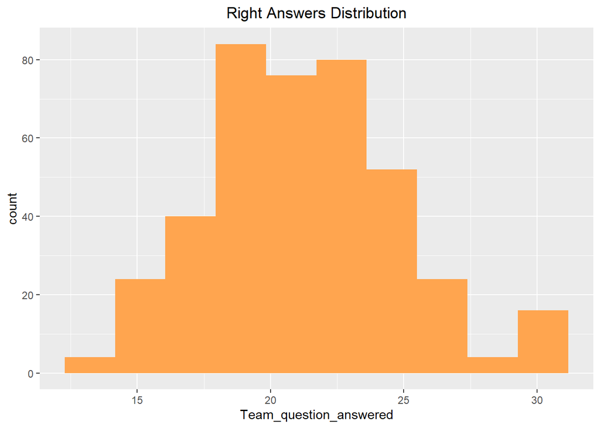

```r
questions_dist <- ggplot(chaser, aes(x=Team_question_answered)) +
  geom_histogram(bins=10, fill="tan1") + labs(title="Right Answers Distribution", xlab="Team's right answers") + theme(plot.title = element_text(hjust = 0.5))

questions_dist
```

- The Age distribution:

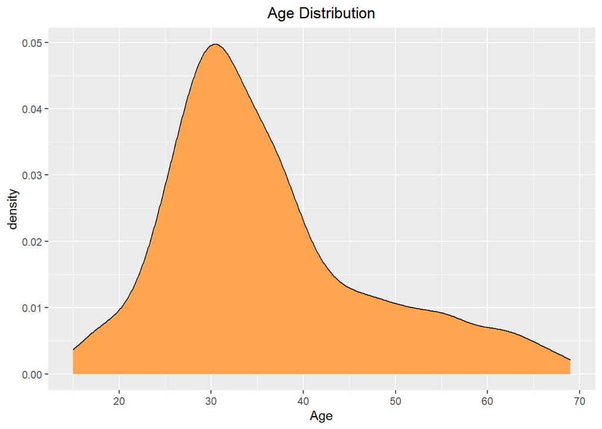

```r
ggplot(data=chaser, aes(x= Age)) +
  geom_density(fill="tan1") + labs(title="Age Distribution", xlab="Age") + theme(plot.title = element_text(hjust = 0.5))
```

- Lets check for Age Outliers by Gender:

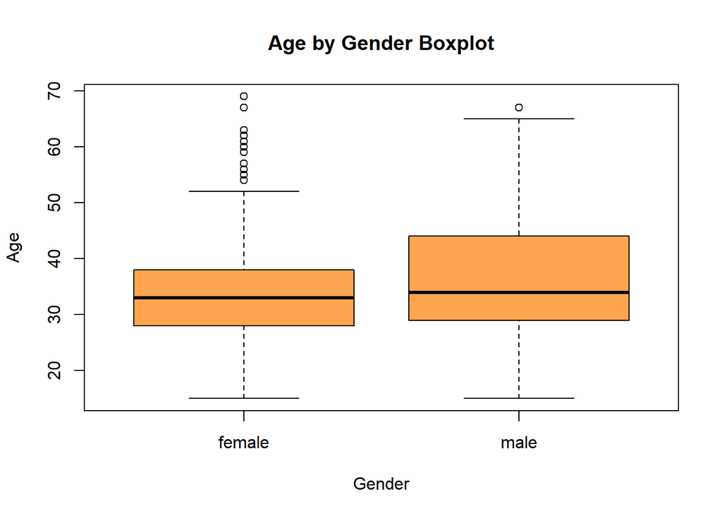

```r
boxplot(chaser$Age~chaser$Gender, main="Age by Gender Boxplot",
        xlab='Gender', ylab='Age', col="tan1")
```

- Lets see the Fast Round total money distribution:

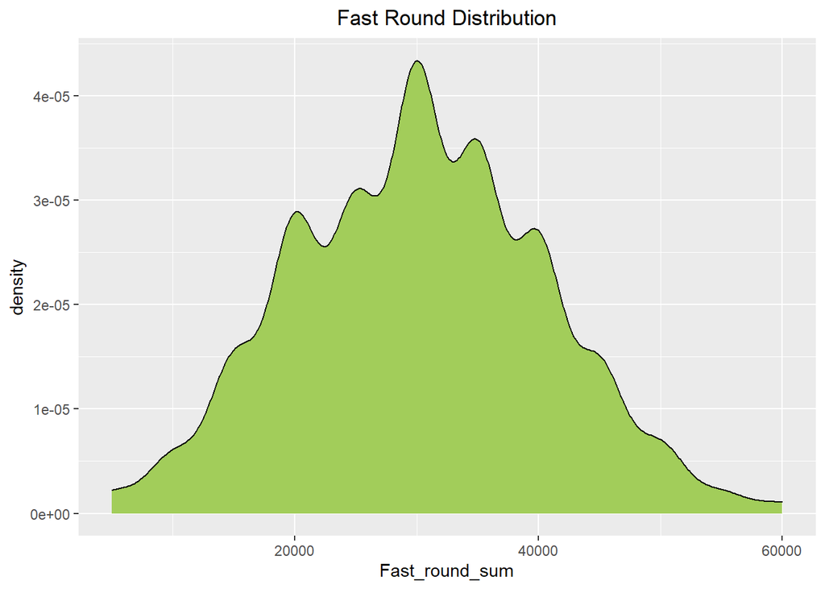

```r
ggplot(data=chaser, aes(x= Fast_round_sum)) +
  geom_density(fill="darkolivegreen3") + labs(title="Fast Round Distribution", xlab="Fast Round Sum") + theme(plot.title = element_text(hjust = 0.5))
```

- We’ll try to understand better if our variables distributions are normal using qq plots, if it is - we expect to see a clear straight line:

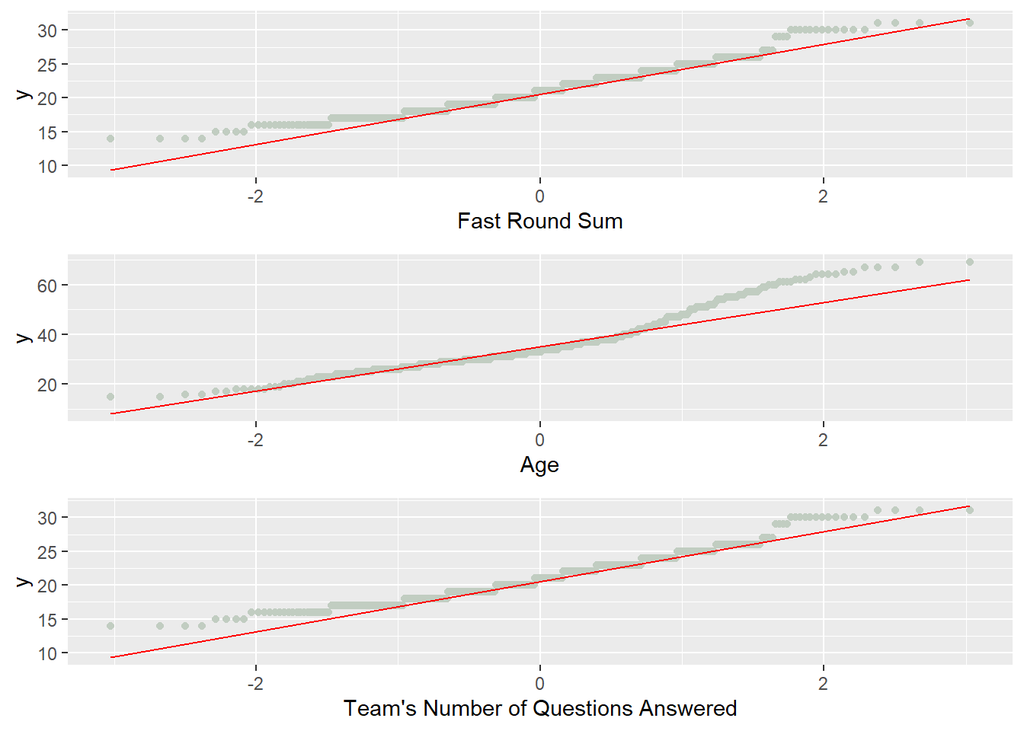

```r
plt_fast_round <- ggplot(chaser, aes(sample=Team_question_answered)) +
  geom_qq(color = "honeydew3") + geom_qq_line(col="red") +
    labs(x= "Fast Round Sum")

plt_age <- ggplot(chaser, aes(sample=Age)) +
  geom_qq(color = "honeydew3") + geom_qq_line(col="red") +
    labs(x= "Age")

plt_question <- ggplot(chaser, aes(sample=Team_question_answered)) +
  geom_qq(color = "honeydew3") + geom_qq_line(col="red") +
    labs(x= "Team's Number of Questions Answered")


grid.arrange(plt_fast_round,plt_age,plt_question)
```

- Lets check the connection between the age, the fast round sum and the gender:

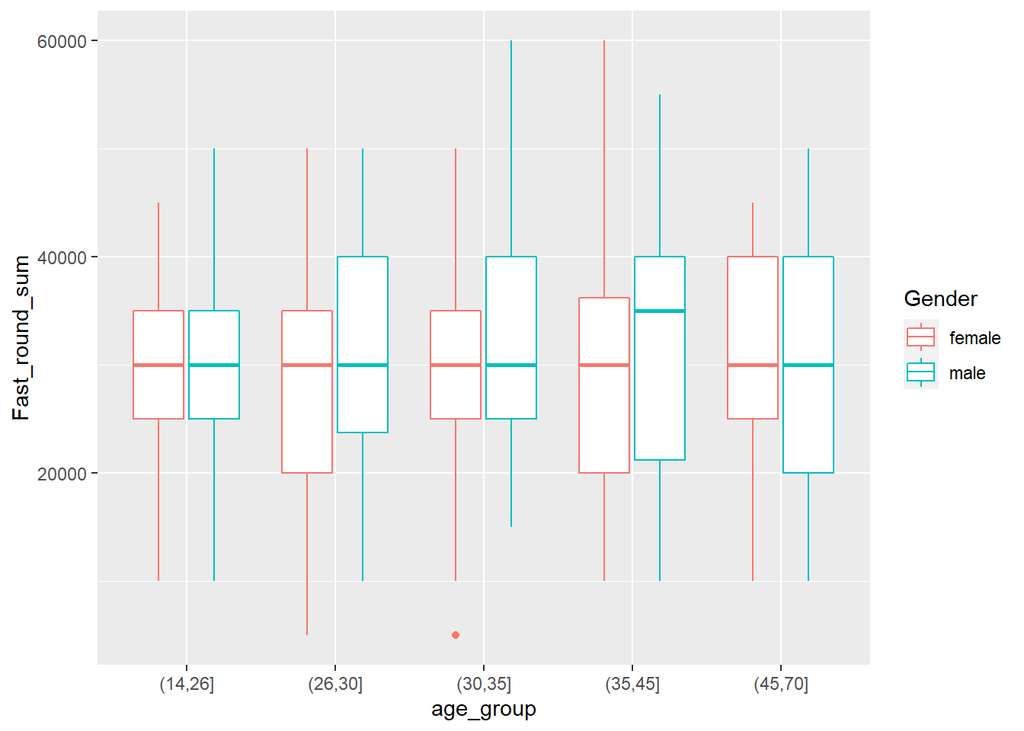

```r
ages <- c(14, 26, 30, 35, 45 ,70)
chaser_by_age <- chaser %>%
  mutate(age_group = cut(Age, ages))

ggplot(data = chaser_by_age, aes(x = age_group, y = Fast_round_sum,
color = Gender)) + geom_boxplot()
```

Based on the plot we can suppose that:

- The median of the fast round amount is 30k.
- The median is pretty much in the same range for each age group and gender (except for the age group of 35-45).
- Also there are only one outlier, so we don’t have to deal with extreme values.

### Statistic Tests

- **We want to perform a T-test on the average age of the players according to their gender and a var test on the standard deviation of the ages.**
- First, Lets takes a look at the age distribution of both male and female players:

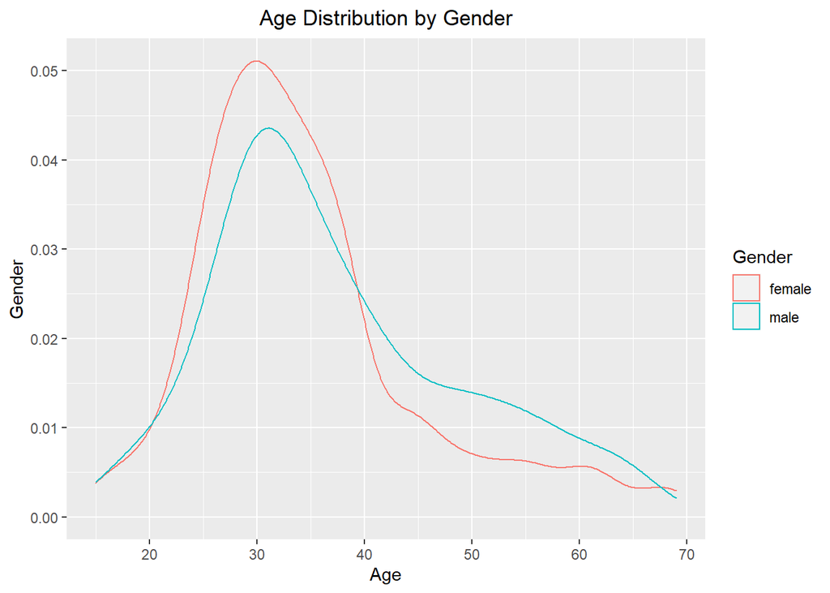

```r
ggplot(data=chaser, aes(x= Age, color = Gender)) +
  geom_density() + labs(title="Age Distribution by Gender",
                    y = "Gender", x = "Age") +  theme(plot.title = element_text(hjust = 0.5))
```

```r
male_players_age <- chaser %>%
  filter(Gender == "male") %>%
  select(Age) %>%
  as.matrix()

female_players_age <- chaser %>%
  filter(Gender == "female") %>%
  select(Age) %>%
  as.matrix()
```

- Lets perform a var test on the std of the age according to gender:
  - H0- the proportion between the variances is 1
  - H1 - the proportion between the variances is not 1

```r
var.test(male_players_age, female_players_age, alternative = "two.sided")
```

```
##
##  F test to compare two variances
##
## data:  male_players_age and female_players_age
## F = 1.181, num df = 201, denom df = 201, p-value = 0.2392
## alternative hypothesis: true ratio of variances is not equal to 1
## 95 percent confidence interval:
##  0.8950068 1.5583513
## sample estimates:
## ratio of variances
##           1.180989
```

- Lets perform the T-test on the average age according to gender:
  - H0 - Male’s average age is equal to the Female’s average age
  - H1 - Male’s average age is greater than the Female’s average age

```r
t.test(male_players_age, female_players_age,alternative = "greater", var.equal = TRUE)
```

```
##
##  Two Sample t-test
##
## data:  male_players_age and female_players_age
## t = 2.3727, df = 402, p-value = 0.009065
## alternative hypothesis: true difference in means is greater than 0
## 95 percent confidence interval:
##  0.8021452       Inf
## sample estimates:
## mean of x mean of y
##  37.36634  34.73762
```

- We can understand two things from the tests:
  - With a p-value of 0.2392 we can not reject H0 in the **var-test** and say that in a 95% confidence level - **both the age distribution of men and women, have the same variance.**
  - With a p-value of 0.009065 we can reject H0 in the **T-test** and say that in a 95% confidence level - **the mean of male players age is greater than the mean of the female players age.**

##### **Now we are going to check the distributions of players who took risks**

(while - 1 represents if the player was willing to take the risk and 0 otherwise.)

Lets start with seeing which kind of risk takers we have:

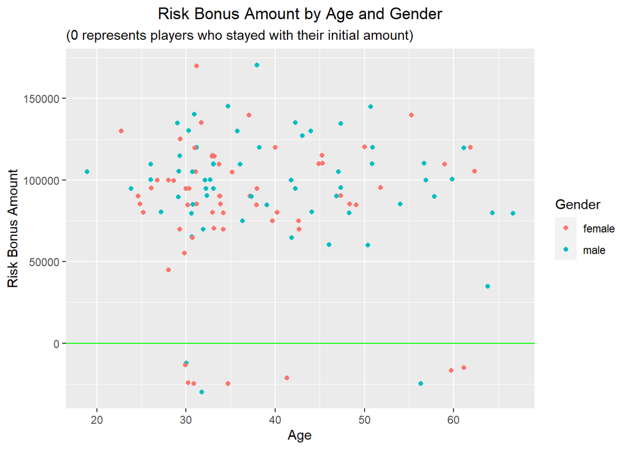

```r
risk_plot <- chaser %>%
  filter(risk_bonus != 0) %>%
  ggplot(aes(x=Age, y=risk_bonus, color=Gender)) +
  geom_jitter() + geom_abline(y=0, color="green") + labs(title="Risk Bonus Amount by Age and Gender", subtitle = "(0 represents players who stayed with their initial amount)", y = "Risk Bonus Amount", x = "Age") +  theme(plot.title = element_text(hjust = 0.5))
risk_plot
```

- We can see a few interesting things regard the players who chose to **take a smaller amount** in order to be one step ahead of the chaser (more chances to win the round):
  - There were only 10 players who chose to be safer out of 404 total (~2.5%)
  - The majority of them are females
  - All of them are older than 30
- As for the players who chose to **take a bigger amount** we can see that most of them are 25-40 years old.

##### **We are going to perform a few Chi-Square tests in order to understand better which variables are independent in our data:**

**1)**

- H0: risk taking and the player number (first/second..) are independently distributed
- H1: risk taking and the player number (first/second..) are dependent variables

```r
by_player <- chaser%>%
  select(player_num, risk_taker) %>%
  dplyr::count(risk_taker,player_num)%>%
  pivot_wider(names_from = "player_num", values_from = "n") %>%
  select(2:5)

chisq.test(by_player)
```

```
##
##  Pearson's Chi-squared test
##
## data:  by_player
## X-squared = 1.9765, df = 3, p-value = 0.5773
```

- The p-value is 0.5773 so we can not reject H0 and therefore the variables are **not dependent** with a confidence-level of 95%.

**2)**

- H0: risk taking and the player gender are independently distributed
- H1: risk taking and the player gender are dependent variables

```r
sum_risk_takers <- colSums(chaser[,c("risk_taker")])

by_gender <- chaser%>%
  select(Gender, risk_taker) %>%
  dplyr::count(risk_taker, Gender) %>%
  pivot_wider(names_from="Gender", values_from = "n") %>%
  select(2:3)

chisq.test(by_gender)
```

```
##
##  Pearson's Chi-squared test with Yates' continuity correction
##
## data:  by_gender
## X-squared = 0.11118, df = 1, p-value = 0.7388
```

- The p-value is 0.7388 so we can’t reject H0 and therefore the variables are **not dependent** with a confidence-level of 95%.

**3)**

- H0: risk taking and the player’s age group are independently distributed
- H1: risk taking and the player’s age group are dependent variables
- (We will also split it into males age groups and females):

```r
#maximum likelihood for proportions is the amount of successes divided by n
proportion_risk_takers <- colMeans(chaser[,c("risk_taker")])

ages <- c(14, 26, 30, 35, 45 ,70)
by_age <- chaser %>%
  mutate(age_group = cut(Age, ages)) %>%
  dplyr::count(age_group, risk_taker) %>%
  pivot_wider(names_from="age_group", values_from = "n")


by_age_female <-chaser %>%
  filter(Gender == "female") %>%
  mutate(age_group = cut(Age, ages)) %>%
  dplyr::count(age_group, risk_taker) %>%
  pivot_wider(names_from="age_group",values_from = "n")

by_age_male <-chaser %>%
  filter(Gender == "male") %>%
  mutate(age_group = cut(Age, ages)) %>%
  dplyr::count(age_group, risk_taker) %>%
  pivot_wider(names_from="age_group",values_from = "n")

by_age_test <- by_age %>%
  select(2:6)

by_male_age_test <- by_age_male %>%
  select(2:6)

by_female_age_test <- by_age_female %>%
  select(2:6)
```

```r
chisq.test(by_age_test)
```

```
##
##  Pearson's Chi-squared test
##
## data:  by_age_test
## X-squared = 15.632, df = 4, p-value = 0.003555
```

```r
chisq.test(by_male_age_test)
```

```
##
##  Pearson's Chi-squared test
##
## data:  by_male_age_test
## X-squared = 9.6633, df = 4, p-value = 0.0465
```

```r
chisq.test(by_female_age_test)
```

```
##
##  Pearson's Chi-squared test
##
## data:  by_female_age_test
## X-squared = 7.0514, df = 4, p-value = 0.1332
```

- We can see that in general, risk taking and player’s age group are **dependent variables**.
- We can also see that in a 95% confidence level:
  - The age affects the rate in which **Male** players will tend to take risks.
  - But it does **not** affect the **Female** players.

##### Lets visualize the risk taking proportions by age & gender:

(**Note-** there is the exact same amount of male and female players).

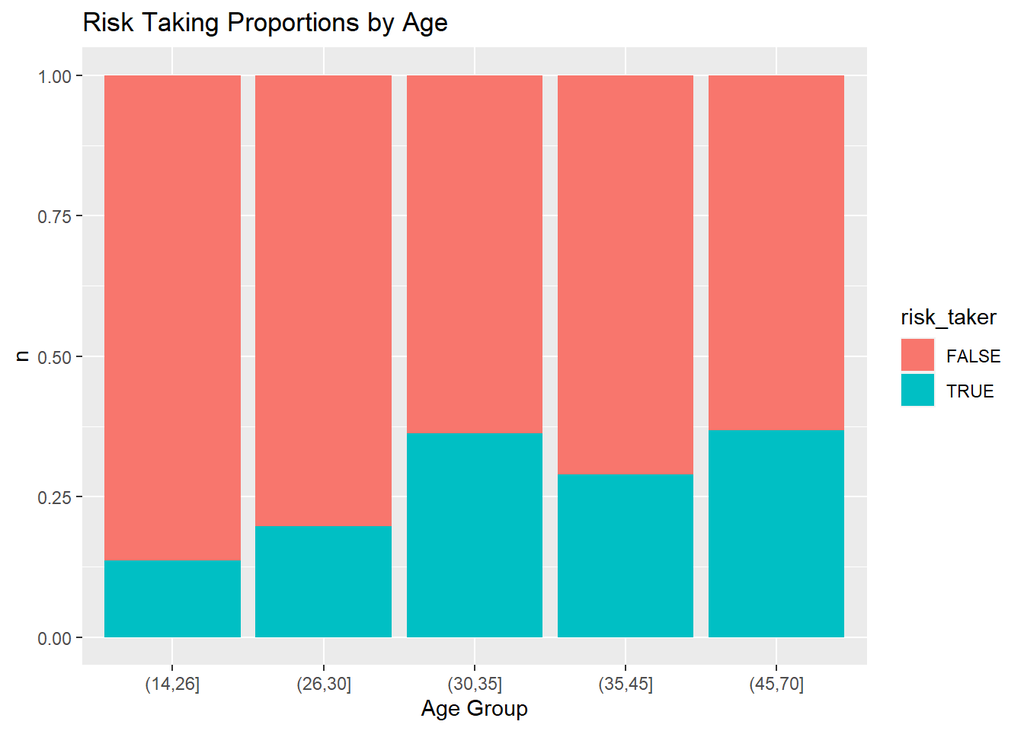

```r
graph_by_age <- chaser %>%
  mutate(age_group = cut(Age, ages)) %>%
  dplyr::count(age_group, risk_taker) %>%
  ggplot(aes(x = age_group,y = n, fill = risk_taker)) +
  geom_bar(stat = "identity", position=position_fill()) +
    labs(title="Risk Taking Proportions by Age", x = "Age Group")

age_and_gender <- chaser%>%
  mutate(age_group = cut(Age, ages))%>%
  group_by(age_group, Gender)%>%
  dplyr::count(risk_taker)%>%
  mutate(freq = n/sum(n)) %>%
  filter(risk_taker == TRUE)%>%
  ggplot(aes(x = age_group, y = freq, fill = Gender)) + geom_bar(stat = "identity",                                                                        position=position_dodge()) +
      labs(title="Risk Taking Proportions by Age and Gender", x = "Age Group")

graph_by_age
```

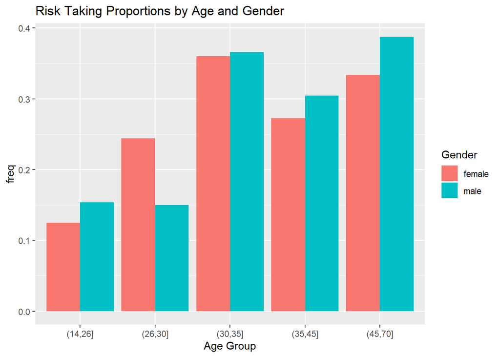

```r
age_and_gender
```

- If we look at all the players in general, we can see that there is an increment in the risk taking proportions as the age increases.
- If we look at the players by gender, we can see a clear correlation between the male players and their risk proportions by age, also the proportions are greatly increased from age of 30+.
- Furthermore, above the age of 30 the players are more likely to take the risk (especially for the male players).

**4)**

- H0: risk taking and the fast round amount (divided to groups) are independently distributed
- H1: risk taking and the fast round amount groups are dependent distributed
- (**Note-** The fast round groups are the amount gained in the fast round divided to different ranges)

```r
fast_round_groups <- c(0, 15, 20, 25, 30, 35, 40,60)

by_fast_round <- chaser %>%
  mutate(fr_k = Fast_round_sum/1000,
         fr_k_groups = cut(fr_k, fast_round_groups)) %>%
  select(fr_k_groups, risk_taker) %>%
  dplyr::count(fr_k_groups, risk_taker) %>%
  pivot_wider(names_from="fr_k_groups", values_from="n")

by_fast_round_test <- by_fast_round %>%
  select(2:8)

chisq.test(by_fast_round_test)
```

```
##
##  Pearson's Chi-squared test
##
## data:  by_fast_round_test
## X-squared = 3.645, df = 6, p-value = 0.7246
```

- The p-value is 0.7246 so we can’t reject H0 and therefore the variables are **not dependent** with a confidence-level of 95%.
- This is quite **surprising-** we thought that as players get more money on the fast round, they will be more reluctant to take risks, and therefore the proportions would decrease. That why we expected to see a clear negative connection, but the test showed that with a confidence-level of 95% they are not dependent.

#### **Now we are going to focus on the winning proportions:**

- We’ll create a new table that represent the whole group:

```r
# Creating groups for the cut function:
sd_groups = c(0, 2.5, 5, 7.5, 10, 12.5, 15, 17.5, 20, 25)
avg_age_groups = c(14, 30, 35, 40, 45, 56)

#Creates a new table which is row is a group:
chaser_by_group <- chaser %>%
  group_by(group_id) %>%
  mutate(Avg_age = mean(Age),
         Avg_age_group = cut(Avg_age, avg_age_groups),
         Sd_age = sd(Age),
         Sd_age_group = cut(Sd_age,sd_groups),
         risk_taker_amount = sum(risk_taker),
         Has_Won = game_result == 1, #True/False
         team_fast_rounds = sum(Fast_round_sum),
         risk_bonus_sum = sum(risk_bonus), #How much the total risks of the group is worth?
         gained = game_result * team_total_sum) %>% #How much money the group got? (0 if lost)
  select(group_id, Avg_age_group, Sd_age,Sd_age_group, Has_Won, Avg_age, risk_taker_amount
         ,team_total_sum, Team_question_answered, team_fast_rounds, risk_bonus_sum, gained) %>%
  distinct() #Delets duplicates

glimpse(chaser_by_group)
```

```
## Rows: 101
## Columns: 12
## Groups: group_id [101]
## $ group_id               <int> 1, 2, 3, 4, 5, 6, 7, 8, 9, 10, 11, 12, 13, 14, 15, 16, 17, 18, 19, 20, 21, 22, 23, 24, 25, 26, 27, 28, 29, 30, 31, 32, 33, 34, 35, 36, 37, 38,~
## $ Avg_age_group          <fct> "(35,40]", "(40,45]", "(35,40]", "(14,30]", "(35,40]", "(40,45]", "(14,30]", "(30,35]", "(35,40]", "(30,35]", "(30,35]", "(40,45]", "(40,45]",~
## $ Sd_age                 <dbl> 13.573872, 16.800298, 11.633286, 4.349329, 9.215024, 9.069179, 7.762087, 7.141428, 11.972190, 2.217356, 4.031129, 16.997549, 10.785793, 11.586~
## $ Sd_age_group           <fct> "(12.5,15]", "(15,17.5]", "(10,12.5]", "(2.5,5]", "(7.5,10]", "(7.5,10]", "(7.5,10]", "(5,7.5]", "(10,12.5]", "(0,2.5]", "(2.5,5]", "(15,17.5]~
## $ Has_Won                <lgl> FALSE, FALSE, FALSE, TRUE, FALSE, FALSE, TRUE, FALSE, FALSE, FALSE, TRUE, FALSE, FALSE, FALSE, TRUE, FALSE, FALSE, TRUE, FALSE, FALSE, FALSE, ~
## $ Avg_age                <dbl> 35.75, 43.75, 40.00, 29.75, 37.25, 42.25, 29.75, 31.50, 40.00, 34.75, 34.75, 42.75, 40.50, 32.75, 36.00, 33.50, 46.25, 36.50, 38.75, 38.75, 35~
## $ risk_taker_amount      <int> 0, 1, 1, 1, 1, 1, 0, 1, 0, 1, 1, 1, 2, 0, 1, 1, 1, 1, 0, 2, 1, 1, 0, 0, 4, 1, 1, 1, 0, 1, 0, 2, 0, 2, 1, 1, 1, 2, 1, 1, 0, 1, 2, 1, 3, 1, 2, 3~
## $ team_total_sum         <dbl> 105000, 215000, 60000, 90000, 70000, 204000, 105000, 175000, 85000, 125000, 240000, 80000, 180000, 105000, 95000, 75000, 185000, 225000, 70000~
## $ Team_question_answered <dbl> 19, 23, 23, 24, 18, 19, 25, 19, 23, 19, 29, 23, 22, 18, 24, 21, 17, 30, 22, 16, 17, 22, 24, 20, 19, 15, 21, 18, 14, 30, 21, 27, 22, 24, 22, 23~
## $ team_fast_rounds       <dbl> 135000, 135000, 100000, 110000, 125000, 150000, 135000, 120000, 110000, 140000, 135000, 150000, 105000, 135000, 100000, 110000, 110000, 160000~
## $ risk_bonus_sum         <dbl> 0, 110000, 100000, 70000, 60000, 99000, 0, 85000, -25000, 130000, 145000, 65000, 210000, 0, 45000, 75000, 95000, 95000, 0, 165000, 78000, 6500~
## $ gained                 <dbl> 0, 0, 0, 90000, 0, 0, 105000, 0, 0, 0, 240000, 0, 0, 0, 95000, 0, 0, 225000, 0, 0, 0, 0, 70000, 0, 0, 0, 180000, 0, 0, 210000, 0, 155000, 0, 0~
```

- Lets check how the group’s average age affects the chances of winning

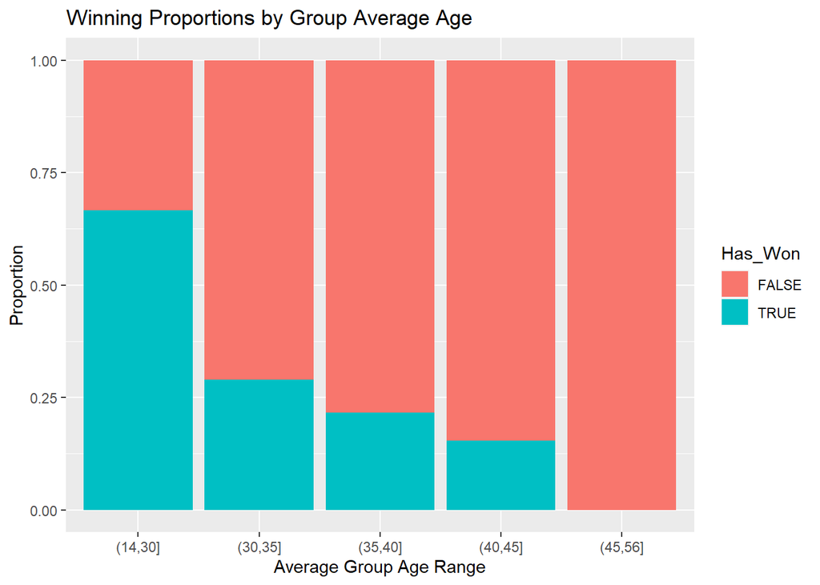

```r
Avg_Age_group_graph <- chaser_by_group %>%
  dplyr::count(Has_Won, Avg_age_group)%>%
  ggplot(aes(x = Avg_age_group, y = n, fill = Has_Won)) +
  geom_bar(stat = "identity", position = position_fill()) +
  labs(title="Winning Proportions by Group Average Age",x = "Average Group Age Range", y = "Proportion")

Avg_Age_group_graph
```

- We can see that groups that their average age was less than 30, had the highest winning rate among the other age groups, and as long as the average age increases, the winning rate decreases!
- Our instincts tell us that since older people have a longer life experience, they will have more chances to answer the questions right. Apparently, in that game it is not necessarily true.
- And what about the age diversity of the group?

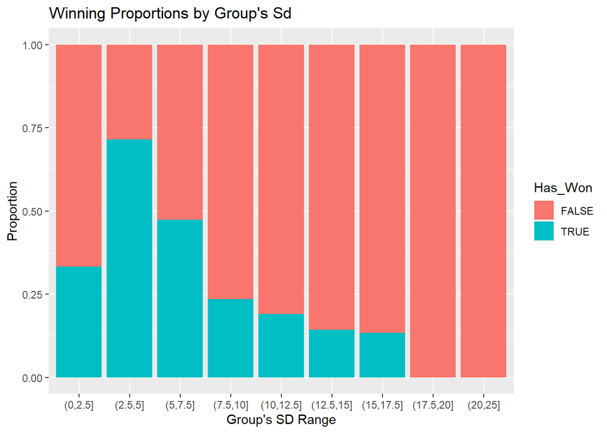

```r
Std_age_group_graph <- chaser_by_group %>%
  group_by(Sd_age_group) %>%
  dplyr::count(Has_Won) %>%
  ggplot(aes(x = Sd_age_group, y = n, fill = Has_Won)) +
  geom_bar(stat = "identity", position = position_fill()) +
  labs(title="Winning Proportions by Group's Sd",x = "Group's SD Range", y = "Proportion")

Std_age_group_graph
```

- Since we realized that the younger age groups had higher winning rate, we thought that maybe a more diversed age group will increase the winning rate since the players might have a broader range of knowledge.
- But it seems like it is best to have a lower sd of age in the group, meaning - groups with more players within the same age range- have higher winning rate (with the exception of 0-2.5).

### Regression Model

### Linear Regression Model:

- Lets take a look at the correlation between our variables:

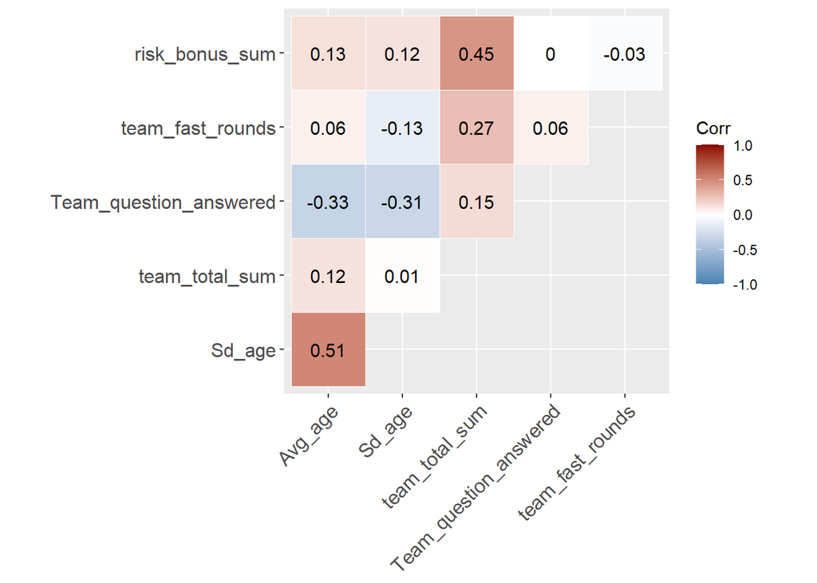

```r
chaser_lm_corr <- chaser_by_group %>%
  ungroup() %>%
  select(Avg_age, Sd_age, team_total_sum, Team_question_answered, team_fast_rounds, risk_bonus_sum, -group_id) %>%
  cor(use = "pairwise.complete.obs")
ggcorrplot::ggcorrplot(chaser_lm_corr,type="upper", lab = T, outline.col = "white",
   ggtheme = ggplot2::theme_gray,
   colors = c("steelblue", "white", "darkred"))
```

- Seems like there is a **negative correlation** between the avg & sd age to the team’s question answered.
- So we’ll try to predict the number of questions that were answered in the last round by the age parameters (avg & sd) of the group.

```r
group_questions_lm <- lm(chaser_by_group, formula = Team_question_answered ~ Avg_age+Sd_age)

summary(group_questions_lm)
```

```
##
## Call:
## lm(formula = Team_question_answered ~ Avg_age + Sd_age, data = chaser_by_group)
##
## Residuals:
##     Min      1Q  Median      3Q     Max
## -8.0146 -2.8938 -0.2808  2.5318  8.1922
##
## Coefficients:
##             Estimate Std. Error t value Pr(>|t|)
## (Intercept) 28.29407    2.35632  12.008   <2e-16 ***
## Avg_age     -0.15207    0.07377  -2.061   0.0419 *
## Sd_age      -0.16124    0.08807  -1.831   0.0702 .
## ---
## Signif. codes:  0 '***' 0.001 '**' 0.01 '*' 0.05 '.' 0.1 ' ' 1
##
## Residual standard error: 3.372 on 98 degrees of freedom
## Multiple R-squared:  0.1354, Adjusted R-squared:  0.1178
## F-statistic: 7.676 on 2 and 98 DF,  p-value: 0.0008002
```

- We can see a **negative correlation** between the average age and the age deviation to the number of questions answered in the final round.
- Though the R-squared is relatively low, the model is **statistically significant** since the p-value is very low.
- With a confidence level of 95% we can say that the average age negatively affects the questions amount, and with a 90% confidence level also the age deviation negatively affects.
- This is **surprising** because we expected to get a positive connection since we thought that older players are likely to have more broader knowledge than younger ones.
- We’ll check for over fitting in our model by the VIF values:

```r
vif(group_questions_lm)
```

```
##  Avg_age   Sd_age
## 1.344137 1.344137
```

- All the VIFs values are lower than 5, that means there is **no over fitting**.
- Lets check the distribution of our model’s **residuals**:

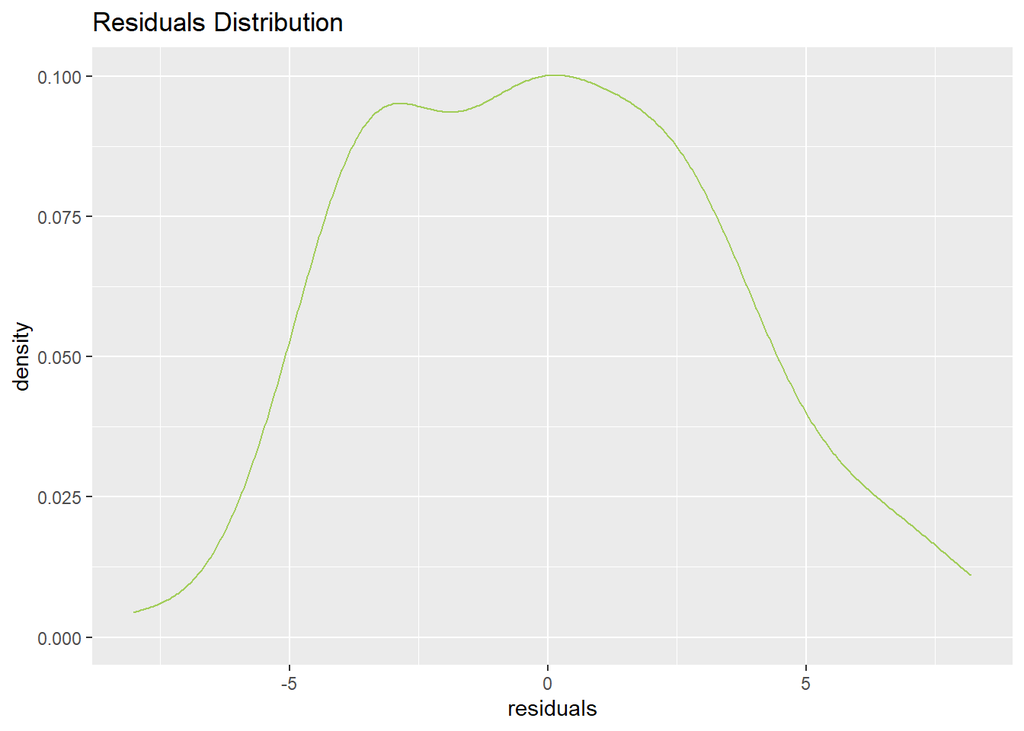

```r
res <- group_questions_lm$residuals
fit <- group_questions_lm$fitted.values

res_table = tibble(res, fit)
ggplot(res_table, aes(x = res)) + geom_density(color="darkolivegreen3") + xlab("residuals") + ggtitle("Residuals Distribution")
```

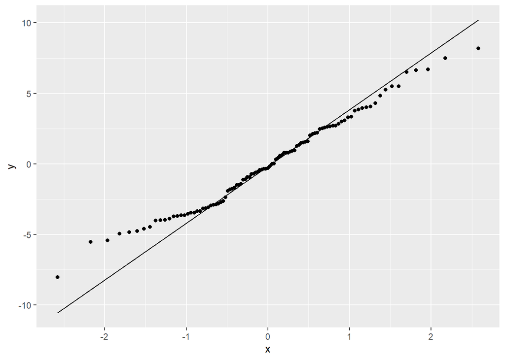

```r
ggplot(res_table, aes(sample=res)) + geom_qq() + geom_qq_line()
```

- It seems like the distribution is close to normal but yet, it is not optimal.
- We’ll check for homoscedasticity in our model:

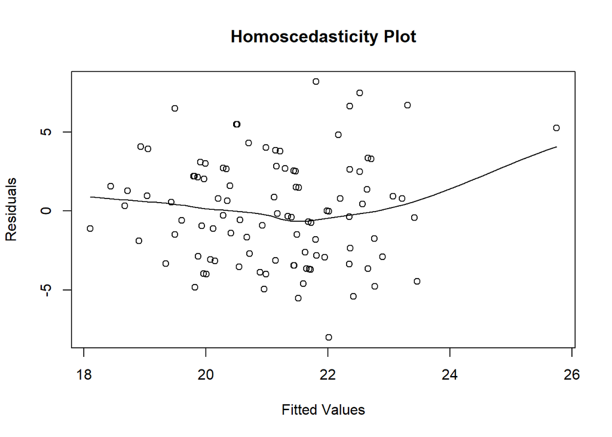

```r
scatter.smooth(x=fit, y=res, main="Homoscedasticity Plot", xlab="Fitted Values", ylab="Residuals")
```

- When it comes to homoscedasticity, the residuals are slightly affected from the fitted values, it is not optimal but we will continue with the model.
- Lets see the model by each variable in a plot:

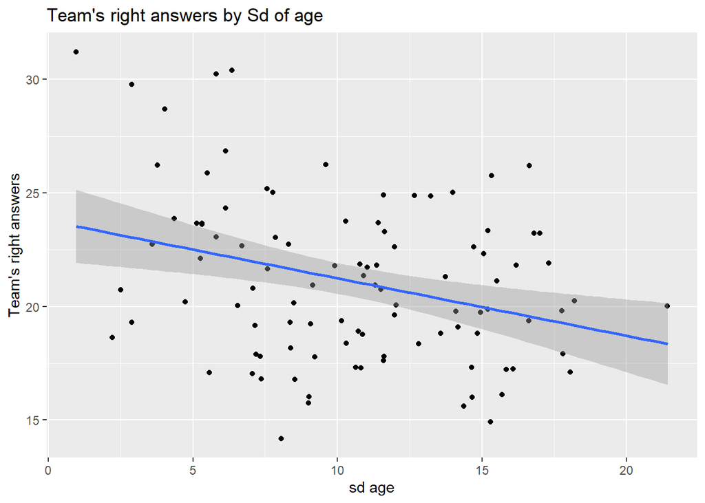

```r
sd_plot <- ggplot(chaser_by_group, aes(x = Sd_age,
                       y = Team_question_answered)) +
  geom_jitter() + stat_smooth(method = "lm") + ggtitle("Team's right answers by Sd of age") +
  xlab("sd age") + ylab("Team's right answers")

avg_plot <- ggplot(chaser_by_group, aes(x = Avg_age,
                       y = Team_question_answered)) +
  geom_jitter() + stat_smooth(method = "lm") + ggtitle("Team's right answers by Average age") +
  xlab("Average age") + ylab("Team's right answers")

sd_plot
```

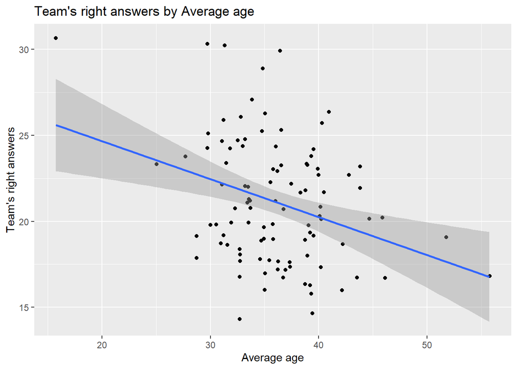

```r
avg_plot
```

##### **What can we understand from that model?**

- In general, younger and homogenize groups are more likely to perform better in the last round (meaning- more likely to win).
- This might be a result of the initial selection of players that don’t necessarily represent knowledge wise among their age demographic.
- Another reason might be that the new younger generation are significantly more exposed, already at an early age, to huge amount of information than any other generation, thanks to the technology and social media. That might explain why younger player succeeded more than the others.